# Checking Audio Data

Kendra Wyant

2020-08-13

### Notes

This script checks data from RISK participants’ transcribed audio check-ins by computing descriptives and checking for missingness and potential errors.

### Setup

Paths

```r
path_data <- "./analysis/shared/data"
```

Packages

```r
library(tidyverse)
library(janitor)
library(lubridate)
library(kableExtra)
library(psych)
library(tidytext)
library(tm)
library(textclean)
library(textrecipes)
```

### Import Data and glimpse

Audio data

```r
audio <- read_rds(file.path(path_data, "ds_audio.rds"))
audio <- audio %>%
  clean_names() %>%
  rename("subid" = "sub_id") %>%
  mutate(date_central = date(as_datetime(utc, tz = 'America/Chicago'))) %>%
  glimpse()
```

```
## Rows: 7,593
## Columns: 4
## $ utc          <dbl> 1488470400, 1488470400, 1488470400, 1488470400, 148…
## $ subid        <int> 1, 1, 1, 1, 1, 1, 1, 1, 1, 1, 1, 1, 1, 1, 1, 1, 1, …
## $ text         <chr> "Calling again.  Candace here.  Sitting at the bank…
## $ date_central <date> 2017-03-02, 2017-03-02, 2017-03-02, 2017-03-02, 20…
```

163 participants contribute to a total of 7593 audio recordings.  
The earliest audio recording is from 2017-03-02 and the last is from 2017-03-02.  
This is because there is only 1 unique utc for entire utc column.  
As a result this script only will be checking message text characteristics and descriptives overall and by subid.

Final dataset

```r
audio <- audio %>%
  select(subid, text) %>%
  glimpse()
```

```
## Rows: 7,593
## Columns: 2
## $ subid <int> 1, 1, 1, 1, 1, 1, 1, 1, 1, 1, 1, 1, 1, 1, 1, 1, 1, 1, 1, 1…
## $ text  <chr> "Calling again.  Candace here.  Sitting at the bank.  Thin…
```

Missing (NA) values

```r
if(any(is.na(audio))){
  missing <- audio %>%
    summarise(across(everything(), ~sum(is.na(.)))) %>%
    gather(key = "var", value = "num_NA" ) %>%
    filter(num_NA > 0)
  missing %>%
    kable(caption = "Variables with missing values", table.attr = "style='width:40%;'") %>%
    kable_styling(position = "left", bootstrap_options = "condensed")
}else {
  paste("No missing values")
}
```

Variables with missing values

| var | num_NA |
| --- | --- |
| text | 1 |

There is 1 missing value (NA) from the dataset. The observation is below however, it is difficult to say why this value is missing because we only have the subid.

```r
audio %>%
  filter(is.na(text)) %>%
   kable(caption = "Observation with missing data",
        table.attr = "style = 'width:40%;'") %>%
  kable_styling(position = "left")
```

Observation with missing data

| subid | text |
| --- | --- |
| 26 | NA |

Blank or notably short audio recordings

```r
audio_short <- audio %>%
  filter(nchar(text) <= 15)

audio_short %>%
  kable(caption = "Audio recordings less than 15 characters in length",
         table.attr = "style = 'width:40%;'") %>%
  kable_styling(position = "left")
```

Audio recordings less than 15 characters in length

| subid | text |
| --- | --- |
| 98 | Oh, I am - |
| 100 | Hi. |
| 103 | (No audio) |
| 110 | *music playing* |
| 117 | Good morning. |
| 128 | Hi, um. |
| 128 | Hi. |
| 188 | Happy Easter. |
| 188 | Doing well. |
| 188 | Happy Friday. |
| 225 | M |
| 242 | [inaudible] |
| 242 | Inaudible |
| 242 | Inaudible |
| 242 | [Inaudible] |
| 264 | Last test. |
| 182 | Working |
| 182 | Working |
| 188 | Feeling well. |
| 188 | Doing well. |
| 222 | *song playing* |
| 237 | Inaudible |

Inaudible messages

```r
contains_inaudible <- audio %>%
  filter(str_detect(tolower(text), "inaudible"))

inaudible_short <- audio %>%
  filter(str_detect(tolower(text), "inaudible")) %>%
  filter(nchar(text) < 100)

inaud_short_bysubid <- inaudible_short %>%
  group_by(subid) %>%
  summarise(n_obs = n())

inaudible_short %>%
  kable(caption = "Shorter audio recordings inaudible for transcription") %>%
  kable_styling(position = "left")
```

Shorter audio recordings inaudible for transcription

| subid | text |
| --- | --- |
| 37 | [Inaudible 0:00:00 – 0:00:31] |
| 135 | It’s Tuesday. I am at the university, feeling [inaudible 0:00:05]. |
| 203 | [Inaudible 0:00:01] to agree having a fine morning. It might be a tough day, but it will be okay. |
| 213 | Went to my [inaudible 0:00:01] today, that was fun. All right, anyway that’s it. |
| 213 | [Inaudible 0:00:01] and I can’t go with my dog and my friends. |
| 213 | Went to my [inaudible 0:00:01] today, that was fun. All right, anyway that’s it. |
| 213 | [Inaudible 0:00:01] and I can’t go with my dog and my friends. |
| 213 | I thought I did this earlier, but yeah, um, I was telling the dog (inaudible 00:08 to take it). |
| 242 | [Inaudible 0:00:00] fucking day. I just can’t wait for this goddamn day to be over. |
| 242 | [Inaudible 0:00:00]. |
| 242 | Had a hard day yesterday. [inaudible 0:00:07] hopefully have a fast recovery. |
| 242 | Alright, [inaudible 0:00:02]. |
| 242 | [Inaudible 0:00:00]. |
| 242 | I fucking worked all night and [inaudible 0:00:02]. |
| 242 | I can’t believe it right now. I [inaudible 0:00:03]. |
| 242 | [inaudible] |
| 242 | [Inaudible 0:00:00]. |
| 242 | [Inaudible 0:00:00]. |
| 242 | [Inaudible 0:00:00]. |
| 242 | [inaudible 0:00:01] |
| 242 | [Inaudible 0:00:00]. |
| 242 | [Inaudible 0:00:00] fucking dump, fuck, sit around. |
| 242 | Inaudible |
| 242 | Oh my god. What a great day (inaudible). Glad and happy to be- |
| 242 | Inaudible |
| 242 | [Inaudible] |
| 242 | [inaudible 0:00:06]. |
| 237 | Inaudible |
| 237 | Good morning everyone. I hope you’re having a good day, um (Inaudible). |
| 237 | No real overwhelming need or want to drink. (Inaudible). Yeah, okay. |

```r
contains_inaudible_total <- contains_inaudible %>%
  group_by(subid) %>%
  summarise(n_obs = n()) %>%
  filter(n_obs > 20)

contains_inaudible_total %>%
  kable(caption = "Participants with more than 20 messages containing inaudible in entire dataset",
        table.attr = "style = 'width:50%;'") %>%
  kable_styling(position = "left")
```

Participants with more than 20 messages containing inaudible in entire dataset

| subid | n_obs |
| --- | --- |
| 242 | 26 |

356 audio recordings have “inaudible” in transcription. However only 30 are short enough (less than 100 characters) for it to likely be a problem. Of these shorter inaudible messages, subid 242 makes up 19 (63.3%) of them.  
Of the entire dataset subid 242 has a total of 26 messages containing inaudible transcription in them.

### Descriptives

#### overall descriptives

Number of audio messages per participant

```r
audio %>%
  group_by(subid) %>%
  summarise(n_obs = n()) %>%
  summarise(mean = round(mean(n_obs), 2),
            sd = round(sd(n_obs), 2),
            min = min(n_obs),
            max = max(n_obs)) %>%
  kable(caption = "Average audio messages per participant",
        table.attr = "style = 'width:40%;'") %>%
  kable_styling(position = "left")
```

Average audio messages per participant

| mean | sd | min | max |
| --- | --- | --- | --- |
| 46.58 | 27.61 | 1 | 92 |

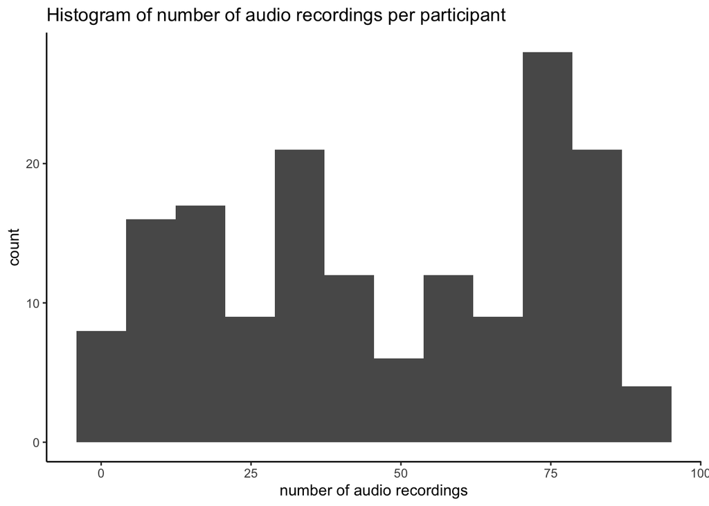

```r
audio %>%
  group_by(subid) %>%
  summarise(n_obs = n()) %>%
  ggplot(aes(x = n_obs)) +
  geom_histogram(bins = 12) +
  xlab("number of audio recordings") +
  ggtitle("Histogram of number of audio recordings per participant") +
  theme_classic()
```

Character length of all audio messages per participant

```r
audio %>%
  mutate(char_length = nchar(text)) %>%
  group_by(subid) %>%
  summarise(total_char = sum(char_length)) %>%
  summarise(mean = round(mean(total_char, na.rm = TRUE), 2),
            sd = round(sd(total_char, na.rm = TRUE), 2),
            min = min(total_char, na.rm = TRUE),
            max = max(total_char, na.rm = TRUE)) %>%
  kable(caption = "Average character length and range of all audio messages per participant",
        table.attr = "style = 'width:70%;'") %>%
  kable_styling(position = "left")
```

Average character length and range of all audio messages per participant

| mean | sd | min | max |
| --- | --- | --- | --- |
| 15730.81 | 14950.1 | 199 | 103969 |

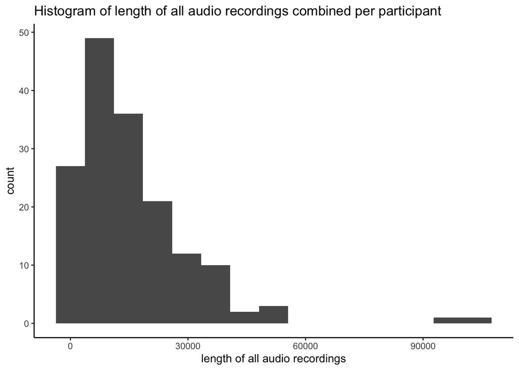

```r
audio %>%
  mutate(char_length = nchar(text)) %>%
  group_by(subid) %>%
  summarise(total_char = sum(char_length)) %>%
  ggplot(aes(x = total_char)) +
  geom_histogram(bins = 15) +
  xlab("length of all audio recordings") +
  ggtitle("Histogram of length of all audio recordings combined per participant") +
  theme_classic()
```

Average character length of each audio message per participant

```r
audio %>%
  mutate(char_length = nchar(text)) %>%
  summarise(mean = round(mean(char_length, na.rm = TRUE), 2),
            sd = round(sd(char_length, na.rm = TRUE), 2),
            min = min(char_length, na.rm = TRUE),
            max = max(char_length, na.rm = TRUE)) %>%
  kable(caption = "Average character length and range of each audio message",
        table.attr = "style = 'width:70%;'") %>%
  kable_styling(position = "left")
```

Average character length and range of each audio message

| mean | sd | min | max |
| --- | --- | --- | --- |
| 335.88 | 276.62 | 1 | 7085 |

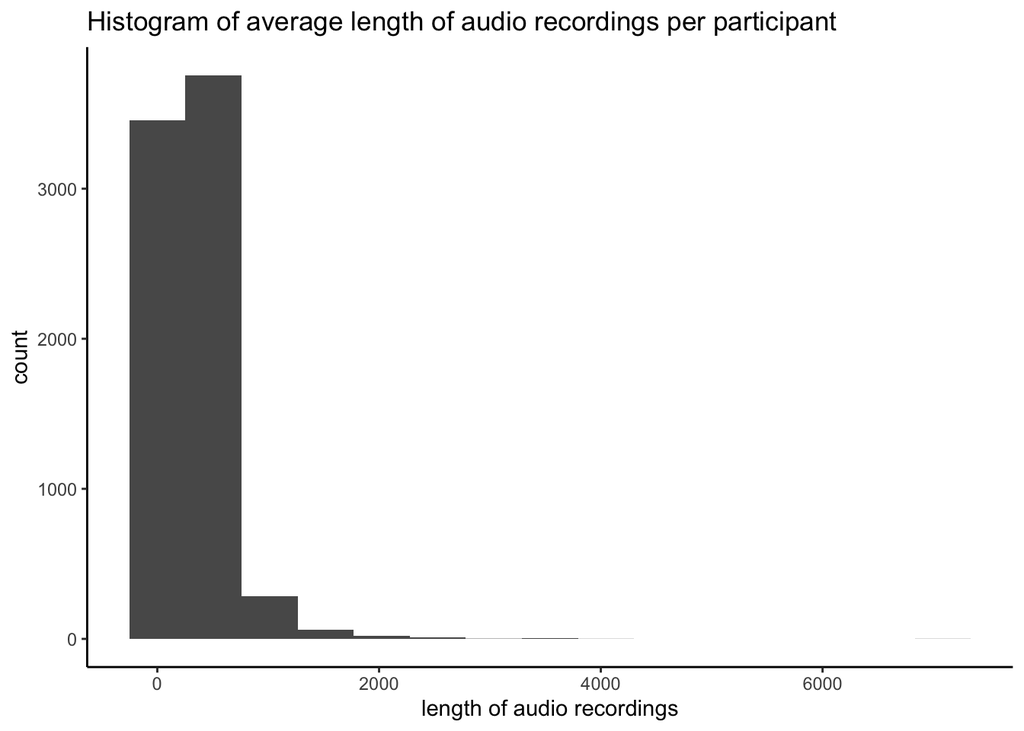

```r
audio %>%
  mutate(char_length = nchar(text)) %>%
  group_by(subid) %>%
  summarise(char_length = nchar(text)) %>%
  ggplot(aes(x = char_length)) +
  geom_histogram(bins = 15) +
  xlab("length of audio recordings") +
  ggtitle("Histogram of average length of audio recordings per participant") +
  theme_classic()
```

#### text analyses

Clean text

```r
audio_tidy <- audio %>%
      mutate(text = removeNumbers(text)) %>%
      mutate(text = tolower(text))%>%
      mutate(text = removePunctuation(text)) %>%
      mutate(text = replace_symbol(text)) %>%
      mutate(text = stripWhitespace(text)) # condenses whitespace into a single space

# Remove new blank text tokens for word count statistics
audio_tidy <- audio_tidy %>%
  filter(!text == " " & !text == "")
```

Tokenize text data (tidy text)

```r
audio_tidy <- audio_tidy %>%
  unnest_tokens(word, text) %>%
  glimpse()
```

```
## Rows: 503,238
## Columns: 2
## $ subid <int> 1, 1, 1, 1, 1, 1, 1, 1, 1, 1, 1, 1, 1, 1, 1, 1, 1, 1, 1, 1…
## $ word  <chr> "calling", "again", "candace", "here", "sitting", "at", "t…
```

Get ML features

```r
audio_features <- audio_tidy %>%
  anti_join(get_stopwords(), by = "word") %>%
  count(subid, word) %>%
  bind_tf_idf(word, subid, n) %>%
  glimpse()
```

```
## Rows: 67,901
## Columns: 6
## $ subid  <int> 1, 1, 1, 1, 1, 1, 1, 1, 1, 1, 1, 1, 1, 1, 1, 1, 1, 1, 1, …
## $ word   <chr> "able", "access", "achc", "actually", "addition", "adjust…
## $ n      <int> 7, 1, 1, 5, 1, 1, 1, 1, 1, 1, 3, 1, 5, 4, 1, 11, 1, 1, 2,…
## $ tf     <dbl> 0.0031305903, 0.0004472272, 0.0004472272, 0.0022361360, 0…
## $ idf    <dbl> 0.5504554, 2.7911651, 5.0937502, 0.4116190, 3.4843123, 3.…
## $ tf_idf <dbl> 0.0017232504, 0.0012482849, 0.0022780636, 0.0009204360, 0…
```

```r
audio_features %>%
  cast_dtm(subid, word, tf_idf)
```

```
## <<DocumentTermMatrix (documents: 163, terms: 9909)>>
## Non-/sparse entries: 67901/1547266
## Sparsity           : 96%
## Maximal term length: 25
## Weighting          : term frequency (tf)
```

Number of unique words per participant

```r
unique_words <- audio_tidy %>%
  group_by(subid) %>%
  summarize(n_unique_words = n_distinct(word))

describe(unique_words$n_unique_words) %>%
  kable(caption = "Number of unique words per participant") %>%
  kable_styling()
```

Number of unique words per participant

|  | vars | n | mean | sd | median | trimmed | mad | min | max | range | skew | kurtosis | se |
| --- | --- | --- | --- | --- | --- | --- | --- | --- | --- | --- | --- | --- | --- |
| X1 | 1 | 163 | 491.4049 | 306.802 | 464 | 463.2214 | 272.7984 | 29 | 1724 | 1695 | 1.11718 | 2.093332 | 24.03059 |

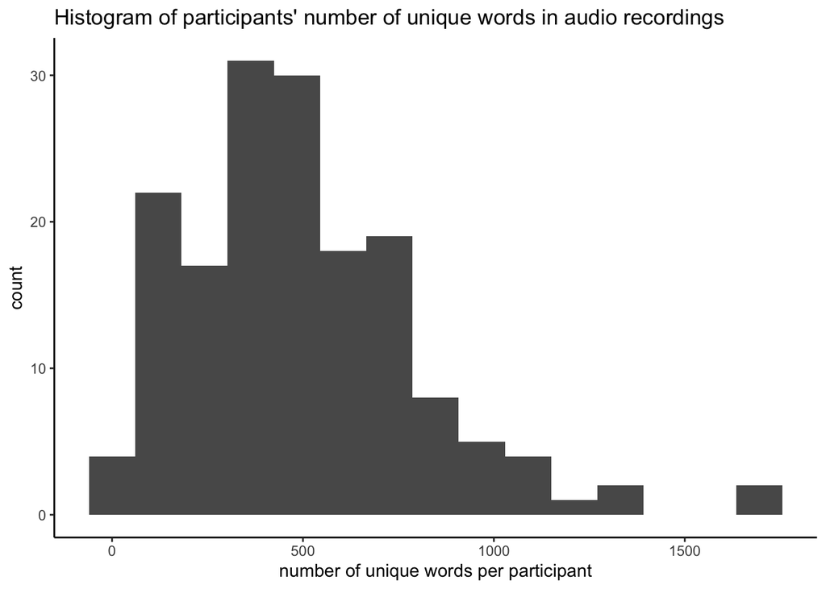

```r
unique_words %>%
  ggplot(aes(x = n_unique_words)) +
  geom_histogram(bins = 15) +
  xlab("number of unique words per participant") +
  ggtitle("Histogram of participants' number of unique words in audio recordings") +
  theme_classic()
```

Top words (common/relevant)

```r
audio_words <- audio_tidy %>%
  count(subid, word, sort = TRUE) %>%
  bind_tf_idf(word, subid, n)

audio_words %>%
  arrange(desc(n)) %>%
  head(n = 20) %>%
  kable(caption = "Most common words by frequency (n)") %>%
  kable_styling(full_width = FALSE, position = "left")
```

Most common words by frequency (n)

| subid | word | n | tf | idf | tf_idf |
| --- | --- | --- | --- | --- | --- |
| 236 | i | 1407 | 0.0741697 | 0.0000000 | 0.0000000 |
| 192 | i | 1297 | 0.0638225 | 0.0000000 | 0.0000000 |
| 25 | i | 871 | 0.0812348 | 0.0000000 | 0.0000000 |
| 128 | i | 870 | 0.0861898 | 0.0000000 | 0.0000000 |
| 192 | and | 838 | 0.0412361 | 0.0000000 | 0.0000000 |
| 236 | and | 725 | 0.0382182 | 0.0000000 | 0.0000000 |
| 143 | uh | 651 | 0.1068615 | 0.0567976 | 0.0060695 |
| 236 | to | 625 | 0.0329468 | 0.0061539 | 0.0002027 |
| 103 | i | 614 | 0.0660641 | 0.0000000 | 0.0000000 |
| 192 | to | 611 | 0.0300659 | 0.0061539 | 0.0001850 |
| 86 | i | 602 | 0.0840195 | 0.0000000 | 0.0000000 |
| 214 | i | 599 | 0.0749875 | 0.0000000 | 0.0000000 |
| 131 | i | 557 | 0.0960676 | 0.0000000 | 0.0000000 |
| 52 | i | 539 | 0.0980356 | 0.0000000 | 0.0000000 |
| 37 | i | 534 | 0.0783451 | 0.0000000 | 0.0000000 |
| 192 | a | 523 | 0.0257357 | 0.0000000 | 0.0000000 |
| 270 | i | 518 | 0.0530683 | 0.0000000 | 0.0000000 |
| 6 | i | 512 | 0.0754272 | 0.0000000 | 0.0000000 |
| 2 | i | 511 | 0.0618794 | 0.0000000 | 0.0000000 |
| 236 | like | 508 | 0.0267791 | 0.1449903 | 0.0038827 |

```r
audio_words %>%
  arrange(desc(tf_idf)) %>%
  head(n = 20) %>%
  kable(caption = "Most relevant words by tf_idf") %>%
  kable_styling(full_width = FALSE, position = "left")
```

Most relevant words by tf_idf

| subid | word | n | tf | idf | tf_idf |
| --- | --- | --- | --- | --- | --- |
| 109 | patricia | 62 | 0.0391661 | 5.093750 | 0.1995025 |
| 56 | shane | 9 | 0.0384615 | 5.093750 | 0.1959135 |
| 109 | jackson | 63 | 0.0397979 | 4.400603 | 0.1751345 |
| 109 | ward | 63 | 0.0397979 | 4.400603 | 0.1751345 |
| 212 | jay | 32 | 0.0366552 | 4.400603 | 0.1613050 |
| 203 | subject | 78 | 0.0387097 | 3.995138 | 0.1546505 |
| 66 | malenga | 19 | 0.0289634 | 5.093750 | 0.1475324 |
| 66 | mulenga | 17 | 0.0259146 | 5.093750 | 0.1320027 |
| 259 | nicole | 69 | 0.0247934 | 5.093750 | 0.1262913 |
| 64 | jones | 1 | 0.0256410 | 4.400603 | 0.1128360 |
| 136 | trinity | 67 | 0.0200419 | 5.093750 | 0.1020883 |
| 79 | deadliest | 1 | 0.0196078 | 5.093750 | 0.0998775 |
| 79 | o’malley | 1 | 0.0196078 | 5.093750 | 0.0998775 |
| 212 | anticipate | 36 | 0.0412371 | 2.260537 | 0.0932180 |
| 29 | confident | 37 | 0.0616667 | 1.482832 | 0.0914413 |
| 64 | robert | 1 | 0.0256410 | 3.301991 | 0.0846664 |
| 64 | waking | 2 | 0.0512821 | 1.510231 | 0.0774478 |
| 64 | blessed | 1 | 0.0256410 | 3.014309 | 0.0772900 |
| 238 | serratta | 43 | 0.0144928 | 5.093750 | 0.0738225 |
| 82 | maintain | 23 | 0.0271547 | 2.695855 | 0.0732050 |

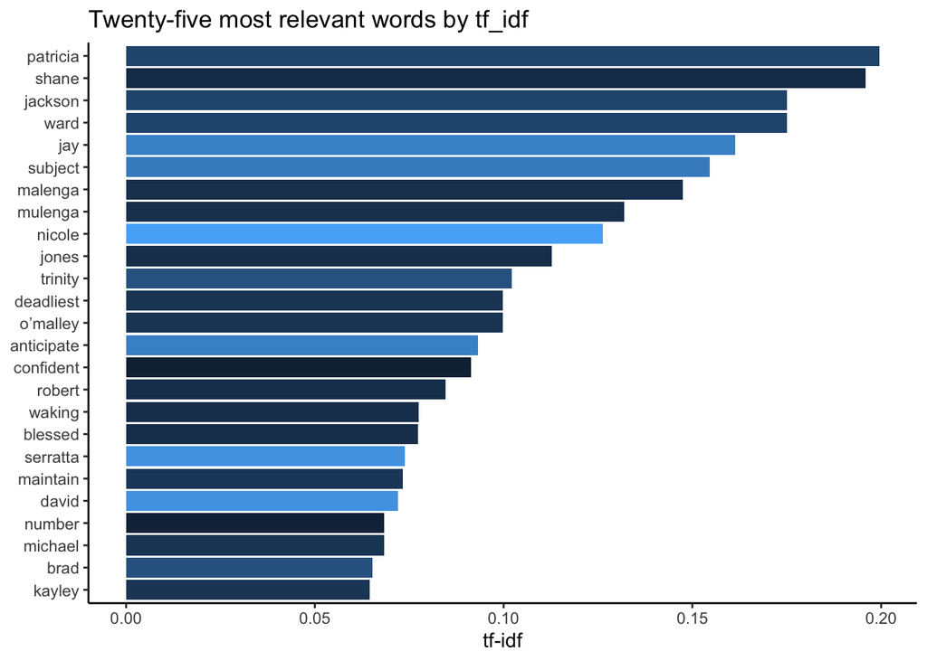

```r
audio_words %>%
  arrange(desc(tf_idf)) %>%
  top_n(25) %>%
  mutate(word = factor(word, levels = rev(unique(word)))) %>%
  ggplot(aes(word, tf_idf, fill = subid)) +
  geom_col(show.legend = FALSE) +
  labs(x = NULL, y = "tf-idf", title = "Twenty-five most relevant words by tf_idf") +
  coord_flip() +
  theme_classic()
```

Example of top ten words (tf-idf) from a single participant

```r
audio %>%
  mutate(char_length = nchar(text)) %>%
  group_by(subid) %>%
  summarise(mean = round(mean(char_length, na.rm = TRUE), 2),
            sd = round(sd(char_length, na.rm = TRUE), 2),
            min = min(char_length, na.rm = TRUE),
            max = max(char_length, na.rm = TRUE)) %>%
  arrange(desc(mean)) %>%
  head(n = 3) %>%
  kable(caption = "Top 3 subids with highest mean character length of audio recordings",
        table.attr = "style = 'width:70%;'") %>%
  kable_styling(position = "left")
```

Top 3 subids with highest mean character length of audio recordings

| subid | mean | sd | min | max |
| --- | --- | --- | --- | --- |
| 192 | 1252.64 | 579.34 | 346 | 3423 |
| 236 | 1205.41 | 1085.45 | 208 | 7085 |
| 131 | 838.12 | 504.26 | 111 | 2011 |

```r
audio_words %>%
  arrange(desc(tf_idf)) %>%
  filter(subid == 192) %>%
  head(n = 10) %>%
  kable(caption = "Subid 192 top words (tf-idf)") %>%
  kable_styling(full_width = FALSE, position = "left")
```

Subid 192 top words (tf-idf)

| subid | word | n | tf | idf | tf_idf |
| --- | --- | --- | --- | --- | --- |
| 192 | spiritual | 35 | 0.0017223 | 3.9951379 | 0.0068807 |
| 192 | connections | 26 | 0.0012794 | 3.7074558 | 0.0047433 |
| 192 | group | 64 | 0.0031493 | 1.4828323 | 0.0046699 |
| 192 | april | 35 | 0.0017223 | 2.4546929 | 0.0042276 |
| 192 | anyway | 107 | 0.0052652 | 0.7630169 | 0.0040175 |
| 192 | march | 33 | 0.0016239 | 2.4546929 | 0.0039861 |
| 192 | hike | 23 | 0.0011318 | 3.3019907 | 0.0037371 |
| 192 | indian | 17 | 0.0008365 | 3.9951379 | 0.0033421 |
| 192 | th | 65 | 0.0031985 | 0.9506155 | 0.0030405 |
| 192 | book | 34 | 0.0016731 | 1.7615457 | 0.0029472 |

```r
audio_words %>%
  arrange(desc(tf_idf)) %>%
  filter(subid == 236) %>%
  head(n = 10) %>%
  kable(caption = "Subid 236 top words (tf-idf)") %>%
  kable_styling(full_width = FALSE, position = "left")
```

Subid 236 top words (tf-idf)

| subid | word | n | tf | idf | tf_idf |
| --- | --- | --- | --- | --- | --- |
| 236 | aa | 64 | 0.0033737 | 1.4561640 | 0.0049127 |
| 236 | like | 508 | 0.0267791 | 0.1449903 | 0.0038827 |
| 236 | community | 21 | 0.0011070 | 3.1478401 | 0.0034847 |
| 236 | nashville | 14 | 0.0007380 | 4.4006030 | 0.0032477 |
| 236 | pneumonia | 14 | 0.0007380 | 4.4006030 | 0.0032477 |
| 236 | sponsor | 28 | 0.0014760 | 2.0492278 | 0.0030247 |
| 236 | she | 72 | 0.0037955 | 0.7499448 | 0.0028464 |
| 236 | lying | 17 | 0.0008962 | 3.0143087 | 0.0027013 |
| 236 | recovery | 53 | 0.0027939 | 0.8890576 | 0.0024839 |
| 236 | bedbugs | 9 | 0.0004744 | 5.0937502 | 0.0024166 |

```r
audio_words %>%
  arrange(desc(tf_idf)) %>%
  filter(subid == 131) %>%
  head(n = 10) %>%
  kable(caption = "Subid 131 top words (tf-idf)") %>%
  kable_styling(full_width = FALSE, position = "left")
```

Subid 131 top words (tf-idf)

| subid | word | n | tf | idf | tf_idf |
| --- | --- | --- | --- | --- | --- |
| 131 | sophia | 30 | 0.0051742 | 5.0937502 | 0.0263561 |
| 131 | al | 15 | 0.0025871 | 3.7074558 | 0.0095916 |
| 131 | sniffs | 47 | 0.0081062 | 0.9040955 | 0.0073288 |
| 131 | anyway | 35 | 0.0060366 | 0.7630169 | 0.0046060 |
| 131 | gift | 6 | 0.0010348 | 4.4006030 | 0.0045539 |
| 131 | he | 30 | 0.0051742 | 0.8596437 | 0.0044480 |
| 131 | pokemon | 5 | 0.0008624 | 5.0937502 | 0.0043927 |
| 131 | risers | 5 | 0.0008624 | 5.0937502 | 0.0043927 |
| 131 | solstice | 5 | 0.0008624 | 5.0937502 | 0.0043927 |
| 131 | him | 22 | 0.0037944 | 0.9348671 | 0.0035473 |